# PROJECT ON CENSUS INCOME DATASET

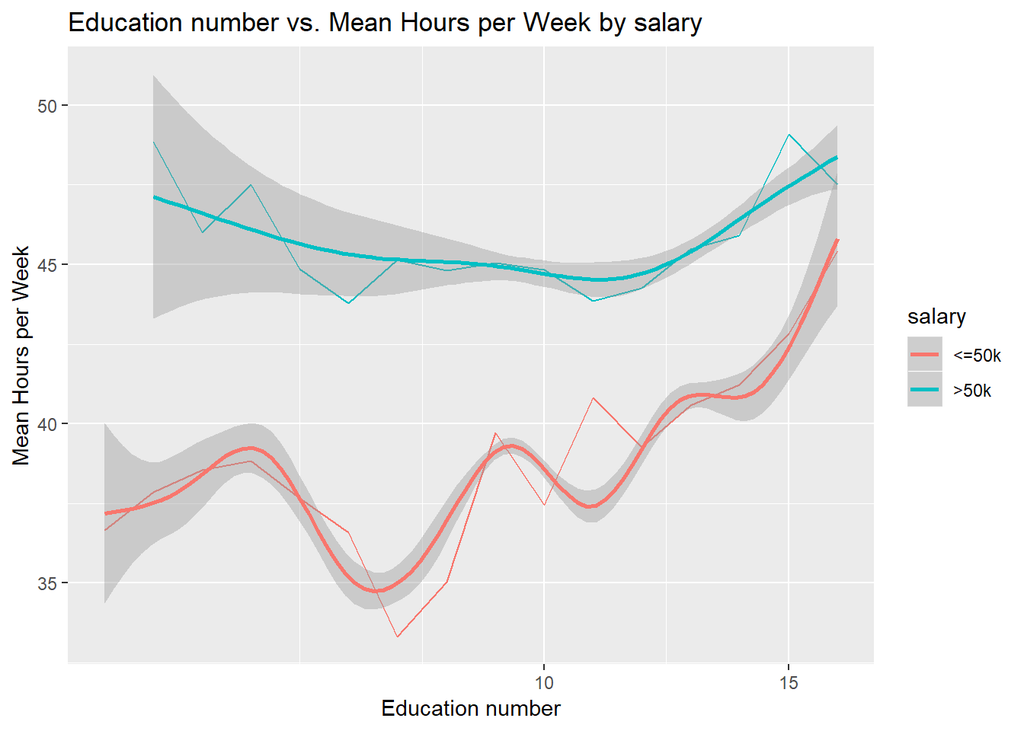

```r
ggplot(aes(x = educationnum, y = hoursperweek),data = adult) + geom_line(mapping = aes(color = salary),stat = 'summary', fun.y = mean) + geom_smooth(mapping = aes(color = salary)) +scale_x_continuous(breaks = seq(10, 100, 5)) + scale_y_continuous(breaks = seq(0, 55, 5)) +
  labs(x = "Education number", y = "Mean Hours per Week") +
  ggtitle("Education number vs. Mean Hours per Week by salary")
```

- From the above graph we can see that people who earn >50k works for 43 hours or more than that whereas people who earn less than 50k works for less 40 hours.
- For people earning >50k, as education number goes beyond 12 years working hour increases.
- For people earninf <= 50k,if education is less than 10 years their working hour is less than 40 hours,as education number increases beyond 12 years their working hours also increases.

```r
a1<-select(adult,educationnum,hoursperweek,salary)
 a1<- group_by(a1,salary)
 a1<- summarise(a1,average_educationyears= mean(educationnum,rm.na=TRUE),average_working_hours=       mean(hoursperweek,rm.na=TRUE))
 a2<- select(a1,everything())
 a2
```

```
## # A tibble: 2 x 3
##   salary average_educationyears average_working_hours
##   <fct>                   <dbl>                 <dbl>
## 1 <=50k                    9.60                  38.8
## 2 >50k                    11.6                   45.5
```

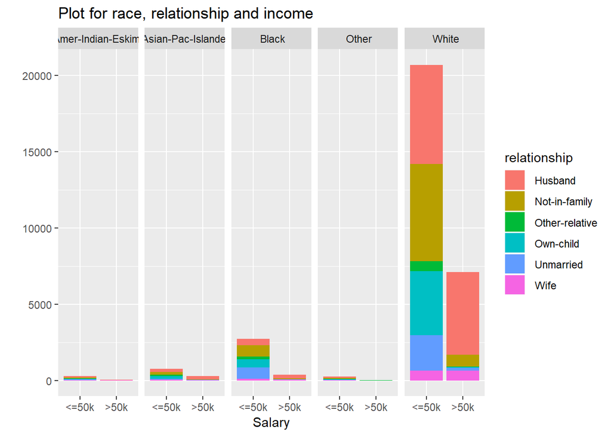

```r
qplot(x=adult$salary, data = adult, fill = relationship) + facet_grid (. ~ race)+labs(x="Salary")+ggtitle("Plot for race, relationship and income")
```

- People who are earning less than 50k majority of them are white male married workers closely followed by the blacks and the Asia-Pacific islanders whereas people who are earning >50k are also white male married but are very less in number .

```r
table(adult$salary,adult$relationship,adult$race)
```

```
## , ,  =  Amer-Indian-Eskimo
##
##
##          Husband  Not-in-family  Other-relative  Own-child  Unmarried
##   <=50k       75             73              12         48         56
##   >50k        17              8               1          0          2
##
##          Wife
##   <=50k    11
##   >50k      8
##
## , ,  =  Asian-Pac-Islander
##
##
##          Husband  Not-in-family  Other-relative  Own-child  Unmarried
##   <=50k      206            189              76        168         82
##   >50k       204             25               6          5          9
##
##          Wife
##   <=50k    42
##   >50k     27
##
## , ,  =  Black
##
##
##          Husband  Not-in-family  Other-relative  Own-child  Unmarried
##   <=50k      417            759             163        553        743
##   >50k       254             53               1          2         26
##
##          Wife
##   <=50k   102
##   >50k     51
##
## , ,  =  Other
##
##
##          Husband  Not-in-family  Other-relative  Own-child  Unmarried
##   <=50k       65             70              26         36         37
##   >50k        15              3               2          1          0
##
##          Wife
##   <=50k    12
##   >50k      4
##
## , ,  =  White
##
##
##          Husband  Not-in-family  Other-relative  Own-child  Unmarried
##   <=50k     6512           6358             667       4196       2310
##   >50k      5428            767              27         59        181
##
##          Wife
##   <=50k   656
##   >50k    655
```

- Maximum people who earn <=50k are white married male followed by a person who doesnot have a family.

## Conclusion Multivariate Distribution

- In this study of predicting a person’s income based on different variables like age,gender,marital status etc. We found in exploring this particular dataset that,the sample is unevenly distributed. All of the Pearson’s chi-square tests give very small p-values, which means that it is very likely for the considered categorical variables - “education”, “marital_status”, “relationship”, “native_country” and “hours_per_week” to be related with “salary”. T-Test of “age” also proves that “salary” dependent on age.
- People who work for more hours in a week as compared to people working for less hours in same age group earns more.
- For the age group of 25 to 85 years more educated people earn more than 50k than the people who are less educated in the same age group.
- People who work for more than 43 hours are likely to earn >50k .On the other hand people who work for less than 40hours earns <50k.
- Maximum working class people are married male of white race and belongs to age group of 25 to 55 years.
- Go to top:Table of Contents

# Predictive Modeling

**Problem Statement**

*“Given various features, the aim is to build a predictive model to determine the income level for people in US. The income levels are binned at below 50K and above 50K.”*

From the problem statement, it’s evident that this is a binary classification problem.

In quest of better accuracy, we’ll use various techniques used on imbalanced classification. For binary classification problem we can apply different machine learning algorithms:

1. Logistic Regression Model
2. Decision Tree Model
3. Random Forest Model

### Now let’s apply various algorithm to build the model and test their predictive power.

# Logistic Regression Model

#### Correlation between numerical variable

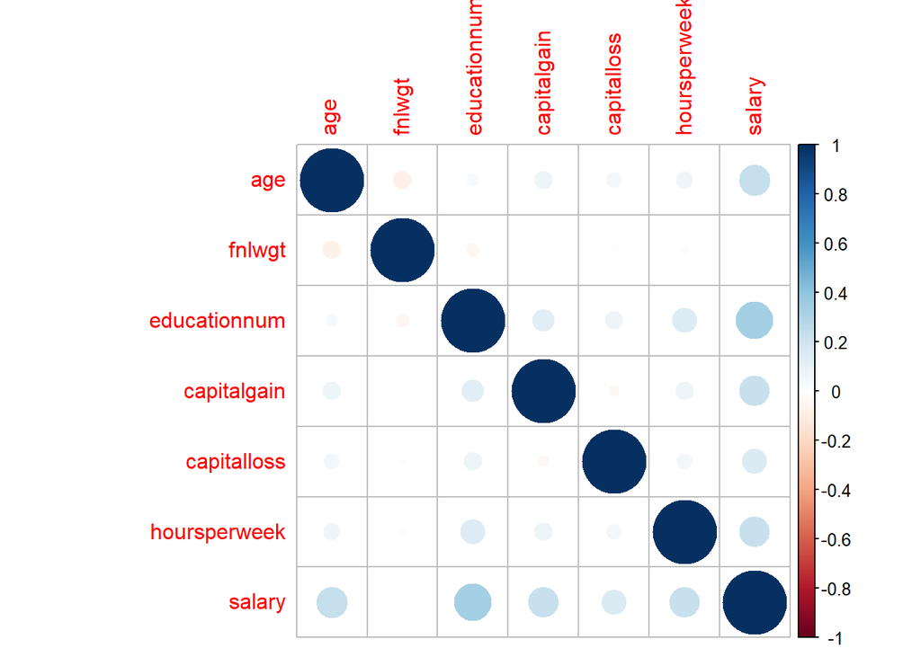

```r
library(corrplot)
adult$salary <- as.numeric(adult$salary)-1  #Changing salary to 0, 1
#Correlation plot
var <- c(1, 3, 5, 11:13, 15)
corrplot(cor(adult[,var]))
```

```r
adult$salary <- factor(adult$salary, labels=c(" <=50K", " >50K")) #Re-factoring salary
```

From the above correlation plot we can see that finalweight has no relation with output variable salary so we will not consider finalweight in prediction.But first of all let’s check whether accuracy is affected by inclusion of final weight or not.

### Scaling the numerical variables

Feature scaling is a method used to standardize the range of independent variables or features of data. In data processing, it is also known as data normalization and is generally performed during the data preprocessing step.

```r
adult$age <- scale(adult$age)
adult$fnlwgt <- scale(adult$fnlwgt)
adult$educationnum <- scale(adult$educationnum)
adult$capitalgain <- scale(adult$capitalgain)
adult$capitalloss <- scale(adult$capitalloss)
adult$hoursperweek <- scale(adult$hoursperweek)
```

### Creating the train and test dataset

We now divide the data into 70% training set and 30% testing set.

```r
library(caTools)
split  <- sample.split(adult$salary,SplitRatio = 0.7)
train <- subset(adult,split == TRUE  )
test <- subset(adult,split==FALSE)
nrow(train)
```

```
## [1] 22793
```

```r
nrow(test)
```

```
## [1] 9768
```

### Logistic regression with all variables.

The R function that we use to build the logistic regression model is “glm” from the standard R installation (the “stats” package). Since we want to fit a logistic regression model, in “glm” we set “family” to “binomial”.

```r
model1 <- glm(salary~.,data = train,family= "binomial")
summary(model1)
```

```
##
## Call:
## glm(formula = salary ~ ., family = "binomial", data = train)
##
## Deviance Residuals:
##     Min       1Q   Median       3Q      Max
## -4.9851  -0.5025  -0.1812  -0.0192   3.7005
##
## Coefficients: (1 not defined because of singularities)
##                                            Estimate Std. Error z value
## (Intercept)                                -3.24873    0.93328  -3.481
## age                                         0.30115    0.02645  11.385
## Workclass Local-gov                        -0.57976    0.13444  -4.312
## Workclass Never-worked                    -10.57098  604.36787  -0.017
## Workclass Private                          -0.48540    0.11197  -4.335
## Workclass Self-emp-inc                     -0.26316    0.14661  -1.795
## Workclass Self-emp-not-inc                 -0.91375    0.13102  -6.974
## Workclass State-gov                        -0.65651    0.14823  -4.429
## Workclass Without-pay                     -14.37893  419.29614  -0.034
## fnlwgt                                      0.06608    0.02165   3.052
## education 11th                             -0.22792    0.24416  -0.934
## education 12th                              0.41966    0.30198   1.390
## education 1st-4th                          -0.30439    0.51292  -0.593
## education 5th-6th                          -0.60670    0.39226  -1.547
## education 7th-8th                          -0.89629    0.28599  -3.134
## education 9th                              -0.21857    0.29134  -0.750
## education Assoc-acdm                        1.03713    0.20105   5.159
## education Assoc-voc                         1.12078    0.19301   5.807
## education Bachelors                         1.74085    0.17685   9.844
## education Doctorate                         2.90263    0.25064  11.581
## education HS-grad                           0.59833    0.17212   3.476
## education Masters                           2.27706    0.18989  11.992
## education Preschool                       -12.88905  188.92288  -0.068
## education Prof-school                       2.70934    0.23036  11.761
## education Some-college                      0.94831    0.17492   5.421
## educationnum                                     NA         NA      NA
## maritalstatus Married-AF-spouse             2.39767    0.62498   3.836
## maritalstatus Married-civ-spouse            1.90522    0.33272   5.726
## maritalstatus Married-spouse-absent         0.03281    0.26897   0.122
## maritalstatus Never-married                -0.54176    0.10564  -5.129
```

[output cut: 162 more lines]

```
## nativecountry Thailand                   0.097311 .
## nativecountry Trinadad&Tobago            0.114426
## nativecountry United-States              0.096243 .
## nativecountry Vietnam                    0.019137 *
## nativecountry Yugoslavia                 0.988406
## ---
## Signif. codes:  0 '***' 0.001 '**' 0.01 '*' 0.05 '.' 0.1 ' ' 1
##
## (Dispersion parameter for binomial family taken to be 1)
##
##     Null deviance: 25165  on 22792  degrees of freedom
## Residual deviance: 14443  on 22696  degrees of freedom
## AIC: 14637
##
## Number of Fisher Scoring iterations: 14
```

- The summary gives the beta coefficients, Standard error, z Value and p Value. Our model had categorical variables with multiple levels, you we will find a row-entry for each category of that variable. That is because, each individual category is considered as an independent binary variable by the glm().
- Deviance is a measure of goodness of fit of a model. Higher numbers always indicates bad fit.
- Null Deviance, Null deviance shows how well the response is predicted by a model with nothing but an intercept (grand mean).
- Residual deviance is lower than null deviance.Lower value of residual deviance points out that the model has become better.
- AIC, Its full form is Akaike Information Criterion (AIC). This is useful when we have more than one model to compare the goodness of fit of the models.It is a maximum likelihood estimate which penalizes to prevent overfitting. It measures flexibility of the models. .Lower AIC of model is better than the model having higher AIC.
- “Number of Fisher Scoring iterations” tells “how many iterations this algorithm run before it stopped”.

### Predictions-Apply model to the train set

```r
library(caret)
result1 <- predict(model1,train,type="response")
p <- as.factor(ifelse(result1>0.5," >50K"," <=50K"))


#Confusion Matrix
confusionMatrix(p, train$salary)
```

```
## Confusion Matrix and Statistics
##
##           Reference
## Prediction  <=50K  >50K
##      <=50K  16127  2217
##      >50K    1177  3272
##
##                Accuracy : 0.8511
##                  95% CI : (0.8464, 0.8557)
##     No Information Rate : 0.7592
##     P-Value [Acc > NIR] : < 2.2e-16
##
##                   Kappa : 0.5646
##  Mcnemar's Test P-Value : < 2.2e-16
##
##             Sensitivity : 0.9320
##             Specificity : 0.5961
##          Pos Pred Value : 0.8791
##          Neg Pred Value : 0.7354
##              Prevalence : 0.7592
##          Detection Rate : 0.7075
##    Detection Prevalence : 0.8048
##       Balanced Accuracy : 0.7640
##
##        'Positive' Class :  <=50K
##
```

### Predictions-Apply model to the test set

```r
library(caret)
result1 <- predict(model1,test,type="response")
p <- as.factor(ifelse(result1>0.5," >50K"," <=50K"))


#Confusion Matrix
confusionMatrix(p, test$salary)
```

```
## Confusion Matrix and Statistics
##
##           Reference
## Prediction  <=50K  >50K
##      <=50K   6947   987
##      >50K     469  1365
##
##                Accuracy : 0.8509
##                  95% CI : (0.8437, 0.858)
##     No Information Rate : 0.7592
##     P-Value [Acc > NIR] : < 2.2e-16
##
##                   Kappa : 0.5592
##  Mcnemar's Test P-Value : < 2.2e-16
##
##             Sensitivity : 0.9368
##             Specificity : 0.5804
##          Pos Pred Value : 0.8756
##          Neg Pred Value : 0.7443
##              Prevalence : 0.7592
##          Detection Rate : 0.7112
##    Detection Prevalence : 0.8122
##       Balanced Accuracy : 0.7586
##
##        'Positive' Class :  <=50K
##
```

- The classifier returns the accuracy (correct classifications / total classifications) when the model includes all predictors in it.
- Kappa is similar to Accuracy score, but it takes into account the accuracy that would have happened anyway through random predictions.
- Kappa = (Observed Accuracy - Expected Accuracy) / (1 - Expected Accuracy)
- Sensitivity = True Positive Rate (TP/TP+FN) - It says, ‘out of all the positive (majority class) values, how many have been predicted correctly’.
- Specificity = True Negative Rate (TN/TN +FP) - It says, ‘out of all the negative (minority class) values, how many have been predicted correctly’.
- Detection rate is the proportion of the whole sample where the events were detected correctly.
- Balanced Accuracy is the balance between correctly predicting the >50K and <=50k. Balanced Accuracy=(sensitivity+specificity)/2

Let us see, if the model accuracy increases or decreases with the exclusion of final weight variable.

### Logistic regression after dropping final weight variable.

```r
model2 <- glm(train$salary~age+Workclass+education+educationnum+maritalstatus+occupation+relationship+sex+capitalgain+capitalloss+hoursperweek+nativecountry,data = train,family= "binomial")
summary(model2)
```

```
##
## Call:
## glm(formula = train$salary ~ age + Workclass + education + educationnum +
##     maritalstatus + occupation + relationship + sex + capitalgain +
##     capitalloss + hoursperweek + nativecountry, family = "binomial",
##     data = train)
##
## Deviance Residuals:
##     Min       1Q   Median       3Q      Max
## -4.9550  -0.5049  -0.1838  -0.0189   3.7121
##
## Coefficients: (1 not defined because of singularities)
##                                            Estimate Std. Error z value
## (Intercept)                              -2.262e+00  8.745e-01  -2.586
## age                                       2.999e-01  2.639e-02  11.367
## Workclass Local-gov                      -5.680e-01  1.338e-01  -4.246
## Workclass Never-worked                   -1.053e+01  6.047e+02  -0.017
## Workclass Private                        -4.626e-01  1.111e-01  -4.165
## Workclass Self-emp-inc                   -2.375e-01  1.458e-01  -1.629
## Workclass Self-emp-not-inc               -8.907e-01  1.302e-01  -6.842
## Workclass State-gov                      -6.437e-01  1.476e-01  -4.361
## Workclass Without-pay                    -1.433e+01  4.189e+02  -0.034
## education 11th                           -2.262e-01  2.441e-01  -0.927
## education 12th                            4.204e-01  3.015e-01   1.394
## education 1st-4th                        -3.017e-01  5.118e-01  -0.589
## education 5th-6th                        -6.097e-01  3.915e-01  -1.557
## education 7th-8th                        -9.204e-01  2.859e-01  -3.219
## education 9th                            -2.166e-01  2.909e-01  -0.745
## education Assoc-acdm                      1.045e+00  2.006e-01   5.208
## education Assoc-voc                       1.124e+00  1.925e-01   5.841
## education Bachelors                       1.752e+00  1.763e-01   9.936
## education Doctorate                       2.902e+00  2.498e-01  11.616
## education HS-grad                         6.021e-01  1.716e-01   3.508
## education Masters                         2.286e+00  1.893e-01  12.074
## education Preschool                      -1.292e+01  1.889e+02  -0.068
## education Prof-school                     2.723e+00  2.298e-01  11.850
## education Some-college                    9.492e-01  1.745e-01   5.440
## educationnum                                     NA         NA      NA
## maritalstatus Married-AF-spouse           2.409e+00  6.263e-01   3.846
## maritalstatus Married-civ-spouse          1.907e+00  3.319e-01   5.745
```

[output cut: 155 more lines]

```
## nativecountry Thailand                   0.093115 .
## nativecountry Trinadad&Tobago            0.083953 .
## nativecountry United-States              0.059429 .
## nativecountry Vietnam                    0.017123 *
## nativecountry Yugoslavia                 0.928336
## ---
## Signif. codes:  0 '***' 0.001 '**' 0.01 '*' 0.05 '.' 0.1 ' ' 1
##
## (Dispersion parameter for binomial family taken to be 1)
##
##     Null deviance: 25165  on 22792  degrees of freedom
## Residual deviance: 14475  on 22701  degrees of freedom
## AIC: 14659
##
## Number of Fisher Scoring iterations: 14
```

- The summary gives the beta coefficients, Standard error, z Value and p Value. Our model had categorical variables with multiple levels, you we will find a row-entry for each category of that variable. That is because, each individual category is considered as an independent binary variable by the glm().
- Deviance is a measure of goodness of fit of a model. Higher numbers always indicates bad fit.
- Null Deviance, Null deviance shows how well the response is predicted by a model with nothing but an intercept (grand mean).
- Residual deviance is lower than null deviance.Lower value of residual deviance points out that the model has become better.
- AIC, Its full form is Akaike Information Criterion (AIC). This is useful when we have more than one model to compare the goodness of fit of the models.It is a maximum likelihood estimate which penalizes to prevent overfitting. It measures flexibility of the models. .Lower AIC of model is better than the model having higher AIC.
- “Number of Fisher Scoring iterations” tells “how many iterations this algorithm run before it stopped”.

### Predictions-Apply model to the train set

```r
library(caret)
r1 <- predict(model2,train,type="response")
p <- as.factor(ifelse(r1>0.5," >50K"," <=50K"))


#Confusion Matrix
confusionMatrix(p, train$salary)
```

```
## Confusion Matrix and Statistics
##
##           Reference
## Prediction  <=50K  >50K
##      <=50K  16115  2216
##      >50K    1189  3273
##
##                Accuracy : 0.8506
##                  95% CI : (0.8459, 0.8552)
##     No Information Rate : 0.7592
##     P-Value [Acc > NIR] : < 2.2e-16
##
##                   Kappa : 0.5636
##  Mcnemar's Test P-Value : < 2.2e-16
##
##             Sensitivity : 0.9313
##             Specificity : 0.5963
##          Pos Pred Value : 0.8791
##          Neg Pred Value : 0.7335
##              Prevalence : 0.7592
##          Detection Rate : 0.7070
##    Detection Prevalence : 0.8042
##       Balanced Accuracy : 0.7638
##
##        'Positive' Class :  <=50K
##
```

### Predictions-Apply model to the test set

```r
result2 <- predict(model2,test,type = "response")
#Confusion Matrix
p1 <- as.factor(ifelse(result2>0.5," >50K"," <=50K"))
confusionMatrix(p1, test$salary)
```

```
## Confusion Matrix and Statistics
##
##           Reference
## Prediction  <=50K  >50K
##      <=50K   6946   986
##      >50K     470  1366
##
##                Accuracy : 0.8509
##                  95% CI : (0.8437, 0.858)
##     No Information Rate : 0.7592
##     P-Value [Acc > NIR] : < 2.2e-16
##
##                   Kappa : 0.5593
##  Mcnemar's Test P-Value : < 2.2e-16
##
##             Sensitivity : 0.9366
##             Specificity : 0.5808
##          Pos Pred Value : 0.8757
##          Neg Pred Value : 0.7440
##              Prevalence : 0.7592
##          Detection Rate : 0.7111
##    Detection Prevalence : 0.8120
##       Balanced Accuracy : 0.7587
##
##        'Positive' Class :  <=50K
##
```

- There is no significant decrease or increase in accuracy when we drop the final weight feature in the model2.
- The classifier returns the accuracy (correct classifications / total classifications) when the model includes all predictors in it(except finalweight).
- Kappa is similar to Accuracy score, but it takes into account the accuracy that would have happened anyway through random predictions.
- Kappa = (Observed Accuracy - Expected Accuracy) / (1 - Expected Accuracy)
- Sensitivity = True Positive Rate (TP/TP+FN) - It says, ‘out of all the positive (majority class) values, how many have been predicted correctly’.
- Specificity = True Negative Rate (TN/TN +FP) - It says, ‘out of all the negative (minority class) values, how many have been predicted correctly’.
- Prevalence is a numeric value or matrix for the rate of the “positive” class of the data.
- Detection rate is the proportion of the whole sample where the events were detected correctly.
- Detection Prevalence tells What percentage of the full sample was predicted as <=50K.
- Balanced Accuracy is the balance between correctly predicting the >50K and <=50k. Balanced Accuracy=(sensitivity+specificity)/2

Let us see, if the model accuracy increases with the inclusion of significant predictors only.

### Logistic regression with significant independent variables

```r
model3 <- glm(train$salary~age + education + hoursperweek + Workclass + maritalstatus + occupation + relationship + race + sex,data = train,family= "binomial")
summary(model3)
```

```
##
## Call:
## glm(formula = train$salary ~ age + education + hoursperweek +
##     Workclass + maritalstatus + occupation + relationship + race +
##     sex, family = "binomial", data = train)
##
## Deviance Residuals:
##     Min       1Q   Median       3Q      Max
## -2.7262  -0.5612  -0.2137  -0.0322   3.4057
##
## Coefficients:
##                                       Estimate Std. Error z value Pr(>|z|)
## (Intercept)                          -4.590031   0.463656  -9.900  < 2e-16
## age                                   0.342567   0.024857  13.781  < 2e-16
## education 11th                       -0.233219   0.232608  -1.003 0.316041
## education 12th                        0.426610   0.278565   1.531 0.125657
## education 1st-4th                    -0.579929   0.468702  -1.237 0.215973
## education 5th-6th                    -0.743608   0.360512  -2.063 0.039146
## education 7th-8th                    -0.951238   0.274133  -3.470 0.000520
## education 9th                        -0.377046   0.277763  -1.357 0.174643
## education Assoc-acdm                  1.044930   0.189039   5.528 3.25e-08
## education Assoc-voc                   1.152290   0.180979   6.367 1.93e-10
## education Bachelors                   1.782483   0.165738  10.755  < 2e-16
## education Doctorate                   3.020516   0.233827  12.918  < 2e-16
## education HS-grad                     0.585955   0.161343   3.632 0.000282
## education Masters                     2.362113   0.177930  13.276  < 2e-16
## education Preschool                 -11.814485 121.411634  -0.097 0.922481
## education Prof-school                 2.917403   0.213890  13.640  < 2e-16
## education Some-college                0.949048   0.164014   5.786 7.19e-09
## hoursperweek                          0.404578   0.022548  17.943  < 2e-16
## Workclass Local-gov                  -0.536446   0.128561  -4.173 3.01e-05
## Workclass Never-worked               -9.829014 367.333872  -0.027 0.978653
## Workclass Private                    -0.442816   0.106882  -4.143 3.43e-05
## Workclass Self-emp-inc               -0.148335   0.138853  -1.068 0.285389
## Workclass Self-emp-not-inc           -0.819876   0.124406  -6.590 4.39e-11
## Workclass State-gov                  -0.707526   0.142058  -4.981 6.34e-07
## Workclass Without-pay               -13.495351 252.583821  -0.053 0.957390
## maritalstatus Married-AF-spouse       2.170271   0.606619   3.578 0.000347
## maritalstatus Married-civ-spouse      1.800846   0.314087   5.734 9.83e-09
## maritalstatus Married-spouse-absent  -0.007388   0.243837  -0.030 0.975829
```

[output cut: 76 more lines]

```
## race Asian-Pac-Islander             *
## race Black                          *
## race Other
## race White                          **
## sex Male                            ***
## ---
## Signif. codes:  0 '***' 0.001 '**' 0.01 '*' 0.05 '.' 0.1 ' ' 1
##
## (Dispersion parameter for binomial family taken to be 1)
##
##     Null deviance: 25165  on 22792  degrees of freedom
## Residual deviance: 15967  on 22739  degrees of freedom
## AIC: 16075
##
## Number of Fisher Scoring iterations: 13
```

- The summary gives the beta coefficients, Standard error, z Value and p Value. Our model had categorical variables with multiple levels, you we will find a row-entry for each category of that variable. That is because, each individual category is considered as an independent binary variable by the glm().
- Deviance is a measure of goodness of fit of a model. Higher numbers always indicates bad fit.

.

- Null Deviance, Null deviance shows how well the response is predicted by a model with nothing but an intercept (grand mean).
- Residual deviance is lower than null deviance.Lower value of residual deviance points out that the model has become better.
- AIC, Its full form is Akaike Information Criterion (AIC). This is useful when we have more than one model to compare the goodness of fit of the models.It is a maximum likelihood estimate which penalizes to prevent overfitting. It measures flexibility of the models. .Lower AIC of model is better than the model having higher AIC.
- “Number of Fisher Scoring iterations” tells “how many iterations this algorithm run before it stopped”.

### Predictions-Apply model to the train set

```r
library(caret)
r2 <- predict(model3,train,type="response")
p <- as.factor(ifelse(r2>0.5," >50K"," <=50K"))


#Confusion Matrix
confusionMatrix(p, train$salary)
```

```
## Confusion Matrix and Statistics
##
##           Reference
## Prediction  <=50K  >50K
##      <=50K  15977  2486
##      >50K    1327  3003
##
##                Accuracy : 0.8327
##                  95% CI : (0.8278, 0.8375)
##     No Information Rate : 0.7592
##     P-Value [Acc > NIR] : < 2.2e-16
##
##                   Kappa : 0.507
##  Mcnemar's Test P-Value : < 2.2e-16
##
##             Sensitivity : 0.9233
##             Specificity : 0.5471
##          Pos Pred Value : 0.8654
##          Neg Pred Value : 0.6935
##              Prevalence : 0.7592
##          Detection Rate : 0.7010
##    Detection Prevalence : 0.8100
##       Balanced Accuracy : 0.7352
##
##        'Positive' Class :  <=50K
##
```

- The classifier returns the accuracy (correct classifications / total classifications) when the model includes significant predictors in it.
- Kappa is similar to Accuracy score, but it takes into account the accuracy that would have happened anyway through random predictions.
- Kappa = (Observed Accuracy - Expected Accuracy) / (1 - Expected Accuracy)
- Sensitivity = True Positive Rate (TP/TP+FN) - It says, ‘out of all the positive (majority class) values, how many have been predicted correctly’.
- Specificity = True Negative Rate (TN/TN +FP) - It says, ‘out of all the negative (minority class) values, how many have been predicted correctly’.
- Prevalence is a numeric value or matrix for the rate of the “positive” class of the data.
- Detection rate is the proportion of the whole sample where the events were detected correctly.
- Detection Prevalence tells What percentage of the full sample was predicted as <=50K.
- Balanced Accuracy is the balance between correctly predicting the >50K and <=50k.
- Balanced Accuracy=(sensitivity+specificity)/2

### Predictions-Apply model to the test set

```r
result3 <- predict(model3,test,type = "response")
#Confusion Matrix
p2 <- as.factor(ifelse(result3>0.5," >50K"," <=50K"))
confusionMatrix(p2, test$salary)
```

```
## Confusion Matrix and Statistics
##
##           Reference
## Prediction  <=50K  >50K
##      <=50K   6873  1066
##      >50K     543  1286
##
##                Accuracy : 0.8353
##                  95% CI : (0.8278, 0.8426)
##     No Information Rate : 0.7592
##     P-Value [Acc > NIR] : < 2.2e-16
##
##                   Kappa : 0.5125
##  Mcnemar's Test P-Value : < 2.2e-16
##
##             Sensitivity : 0.9268
##             Specificity : 0.5468
##          Pos Pred Value : 0.8657
##          Neg Pred Value : 0.7031
##              Prevalence : 0.7592
##          Detection Rate : 0.7036
##    Detection Prevalence : 0.8128
##       Balanced Accuracy : 0.7368
##
##        'Positive' Class :  <=50K
##
```

- The classifier returns the accuracy (correct classifications / total classifications) when the model includes significant predictors in it.
- Kappa is similar to Accuracy score, but it takes into account the accuracy that would have happened anyway through random predictions.
- Kappa = (Observed Accuracy - Expected Accuracy) / (1 - Expected Accuracy)
- Sensitivity = True Positive Rate (TP/TP+FN) - It says, ‘out of all the positive (majority class) values, how many have been predicted correctly’.
- Specificity = True Negative Rate (TN/TN +FP) - It says, ‘out of all the negative (minority class) values, how many have been predicted correctly’.
- Prevalence is a numeric value or matrix for the rate of the “positive” class of the data.
- Detection rate is the proportion of the whole sample where the events were detected correctly.
- Detection Prevalence tells What percentage of the full sample was predicted as <=50K.
- Balanced Accuracy is the balance between correctly predicting the >50K and <=50k.
- Balanced Accuracy=(sensitivity+specificity)/2

With the inclusion of significant predictors in the model, the classifier accuracy decreases slightly.

### ROC Curve

Often, choosing the best model is sort of a balance between predicting the >50k accurately or <=50k accurately. In other words sensitivity and specificity.

But it would be great to have something that captures both these aspects in one single metric.

This is nicely captured by the ‘Receiver Operating Characteristics’ curve, also called as the ROC curve.

```r
library(ROCR)
```

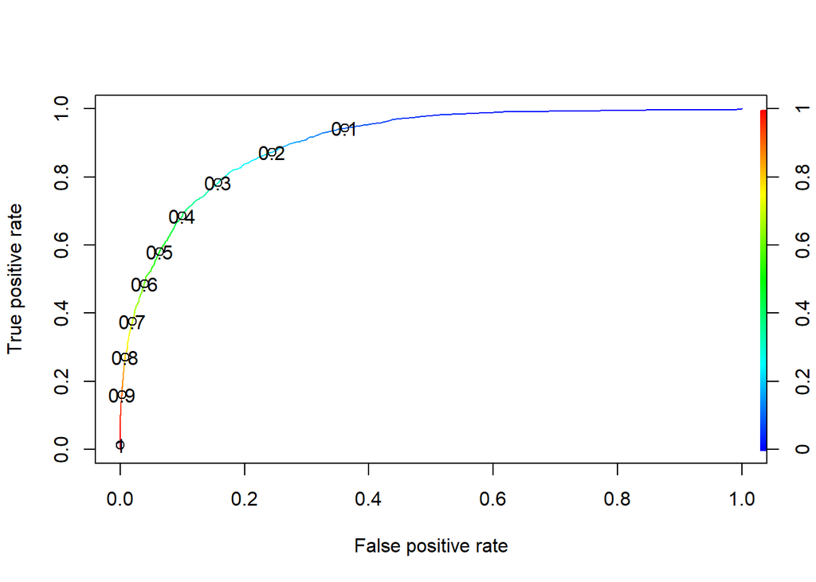

```r
ROCRPred <- prediction(result1,test$salary)
ROCRPref <- performance(ROCRPred,"tpr","fpr")

#plot
plot(ROCRPref,colorize=TRUE,print.cutoffs.at=seq(0.1,by=0.1))
```

Ideally, if you have a perfect model, all the events will have a probability score of 1 and all non-events will have a score of 0. For such a model, the area under the ROC will be a perfect 1.

If we trace the curve from bottom left, the value of probability cutoff decreases from 1 towards 0. A good model, more of the real events should be predicted as events, resulting in high sensitivity. In that case, the curve will rise steeply covering a large area before reaching the top-right.

Therefore, the larger the area under the ROC curve, the better is your model.So we are choosing a cutoff of 0.3 because at 0.3 and after that the line covers majority of the area under the curve.

### Changing the threshold to 0.3 and predicting on train data

```r
res1 <- predict(model1,train,type = "response")
#Confusion Matrix
p3 <- as.factor(ifelse(res1>0.3," >50K"," <=50K"))
confusionMatrix(p3, train$salary)
```

```
## Confusion Matrix and Statistics
##
##           Reference
## Prediction  <=50K  >50K
##      <=50K  14533  1111
##      >50K    2771  4378
##
##                Accuracy : 0.8297
##                  95% CI : (0.8247, 0.8345)
##     No Information Rate : 0.7592
##     P-Value [Acc > NIR] : < 2.2e-16
##
##                   Kappa : 0.5778
##  Mcnemar's Test P-Value : < 2.2e-16
##
##             Sensitivity : 0.8399
##             Specificity : 0.7976
##          Pos Pred Value : 0.9290
##          Neg Pred Value : 0.6124
##              Prevalence : 0.7592
##          Detection Rate : 0.6376
##    Detection Prevalence : 0.6864
##       Balanced Accuracy : 0.8187
##
##        'Positive' Class :  <=50K
##
```

### Changing the threshold to 0.3 and predicting on test data

```r
res1 <- predict(model1,test,type = "response")
#Confusion Matrix
p3 <- as.factor(ifelse(res1>0.3," >50K"," <=50K"))
confusionMatrix(p3, test$salary)
```

```
## Confusion Matrix and Statistics
##
##           Reference
## Prediction  <=50K  >50K
##      <=50K   6247   509
##      >50K    1169  1843
##
##                Accuracy : 0.8282
##                  95% CI : (0.8206, 0.8356)
##     No Information Rate : 0.7592
##     P-Value [Acc > NIR] : < 2.2e-16
##
##                   Kappa : 0.5712
##  Mcnemar's Test P-Value : < 2.2e-16
##
##             Sensitivity : 0.8424
##             Specificity : 0.7836
##          Pos Pred Value : 0.9247
##          Neg Pred Value : 0.6119
##              Prevalence : 0.7592
##          Detection Rate : 0.6395
##    Detection Prevalence : 0.6916
##       Balanced Accuracy : 0.8130
##
##        'Positive' Class :  <=50K
##
```

After the changing the threshold to 0.3 by observing ROC curve the accuracy is almost same as the accuracy when the classifier includes all the independent variable and threshold was 0.5.But there is a significant increase in balanced accuracy as well as specificity.

### Oversampling to increase balanced accuracy

```r
table(train$salary)
```

```
##
##  <=50K   >50K
##  17304   5489
```

```r
library(ROSE) #Randomly OverSampling examples
over <-ovun.sample(salary~.,data=train,method="over",N=34608)$data
table(over$salary)
```

```
##
##  <=50K   >50K
##  17304  17304
```

### Predictive Model

```r
lrover <- glm(salary~.,data = train,family= "binomial")
lrover
```

```
##
## Call:  glm(formula = salary ~ ., family = "binomial", data = train)
##
## Coefficients:
##                              (Intercept)
##                                 -3.24873
##                                      age
##                                  0.30115
##                      Workclass Local-gov
##                                 -0.57976
##                   Workclass Never-worked
##                                -10.57098
##                        Workclass Private
##                                 -0.48540
##                   Workclass Self-emp-inc
##                                 -0.26316
##               Workclass Self-emp-not-inc
##                                 -0.91375
##                      Workclass State-gov
##                                 -0.65651
##                    Workclass Without-pay
##                                -14.37893
##                                   fnlwgt
##                                  0.06608
##                           education 11th
##                                 -0.22792
##                           education 12th
##                                  0.41966
##                        education 1st-4th
##                                 -0.30439
##                        education 5th-6th
##                                 -0.60670
##                        education 7th-8th
##                                 -0.89629
##                            education 9th
##                                 -0.21857
##                     education Assoc-acdm
##                                  1.03713
##                      education Assoc-voc
##                                  1.12078
```

[output cut: 149 more lines]

```
##                                 -1.67353
##                   nativecountry Thailand
##                                 -1.93638
##            nativecountry Trinadad&Tobago
##                                 -2.16087
##              nativecountry United-States
##                                 -1.32860
##                    nativecountry Vietnam
##                                 -2.31280
##                 nativecountry Yugoslavia
##                                  0.01759
##
## Degrees of Freedom: 22792 Total (i.e. Null);  22696 Residual
## Null Deviance:       25160
## Residual Deviance: 14440     AIC: 14640
```

.

- Null Deviance, Null deviance shows how well the response is predicted by a model with nothing but an intercept (grand mean).
- Residual deviance is lower than null deviance.Lower value of residual deviance points out that the model has become better.
- AIC, Its full form is Akaike Information Criterion (AIC). This is useful when we have more than one model to compare the goodness of fit of the models.It is a maximum likelihood estimate which penalizes to prevent overfitting. It measures flexibility of the models. .Lower AIC of model is better than the model having higher AIC.

### Predictive Model Evaluation with test data

```r
result3 <- predict(lrover,test,type = "response")
#Confusion Matrix
p2 <- as.factor(ifelse(result3>0.3," >50K"," <=50K"))
confusionMatrix(p2, test$salary)
```

```
## Confusion Matrix and Statistics
##
##           Reference
## Prediction  <=50K  >50K
##      <=50K   6247   509
##      >50K    1169  1843
##
##                Accuracy : 0.8282
##                  95% CI : (0.8206, 0.8356)
##     No Information Rate : 0.7592
##     P-Value [Acc > NIR] : < 2.2e-16
##
##                   Kappa : 0.5712
##  Mcnemar's Test P-Value : < 2.2e-16
##
##             Sensitivity : 0.8424
##             Specificity : 0.7836
##          Pos Pred Value : 0.9247
##          Neg Pred Value : 0.6119
##              Prevalence : 0.7592
##          Detection Rate : 0.6395
##    Detection Prevalence : 0.6916
##       Balanced Accuracy : 0.8130
##
##        'Positive' Class :  <=50K
##
```

### Undersampling to increase balanced accuracy

```r
under <-ovun.sample(salary~.,data=train,method="under",N=10978)$data
table(under$salary)
```

```
##
##  <=50K   >50K
##   5489   5489
```

By doing undersampling now both the classes has equal number of observations that is 5489 for <=50K and 5489 for >50k.Earlier train dataset had 17304 observations for <=50k class and 5489 observations for >50k class.By doing undersampling we reduced the number of observations to 5489 in both classes which was number of observations in >50k class in train dataset.

### Predictive Model

```r
lrunder <- glm(salary~.,data = train,family= "binomial")
lrunder
```

```
##
## Call:  glm(formula = salary ~ ., family = "binomial", data = train)
##
## Coefficients:
##                              (Intercept)
##                                 -3.24873
##                                      age
##                                  0.30115
##                      Workclass Local-gov
##                                 -0.57976
##                   Workclass Never-worked
##                                -10.57098
##                        Workclass Private
##                                 -0.48540
##                   Workclass Self-emp-inc
##                                 -0.26316
##               Workclass Self-emp-not-inc
##                                 -0.91375
##                      Workclass State-gov
##                                 -0.65651
##                    Workclass Without-pay
##                                -14.37893
##                                   fnlwgt
##                                  0.06608
##                           education 11th
##                                 -0.22792
##                           education 12th
##                                  0.41966
##                        education 1st-4th
##                                 -0.30439
##                        education 5th-6th
##                                 -0.60670
##                        education 7th-8th
##                                 -0.89629
##                            education 9th
##                                 -0.21857
##                     education Assoc-acdm
##                                  1.03713
##                      education Assoc-voc
##                                  1.12078
```

[output cut: 149 more lines]

```
##                                 -1.67353
##                   nativecountry Thailand
##                                 -1.93638
##            nativecountry Trinadad&Tobago
##                                 -2.16087
##              nativecountry United-States
##                                 -1.32860
##                    nativecountry Vietnam
##                                 -2.31280
##                 nativecountry Yugoslavia
##                                  0.01759
##
## Degrees of Freedom: 22792 Total (i.e. Null);  22696 Residual
## Null Deviance:       25160
## Residual Deviance: 14440     AIC: 14640
```

.

- Null Deviance, Null deviance shows how well the response is predicted by a model with nothing but an intercept (grand mean).
- Residual deviance is lower than null deviance.Lower value of residual deviance points out that the model has become better.
- AIC, Its full form is Akaike Information Criterion (AIC). This is useful when we have more than one model to compare the goodness of fit of the models.It is a maximum likelihood estimate which penalizes to prevent overfitting. It measures flexibility of the models. .Lower AIC of model is better than the model having higher AIC.

### Predictive Model Evaluation with test data

```r
result3 <- predict(lrunder,test,type = "response")
#Confusion Matrix
p2 <- as.factor(ifelse(result3>0.3," >50K"," <=50K"))
confusionMatrix(p2, test$salary)
```

```
## Confusion Matrix and Statistics
##
##           Reference
## Prediction  <=50K  >50K
##      <=50K   6247   509
##      >50K    1169  1843
##
##                Accuracy : 0.8282
##                  95% CI : (0.8206, 0.8356)
##     No Information Rate : 0.7592
##     P-Value [Acc > NIR] : < 2.2e-16
##
##                   Kappa : 0.5712
##  Mcnemar's Test P-Value : < 2.2e-16
##
##             Sensitivity : 0.8424
##             Specificity : 0.7836
##          Pos Pred Value : 0.9247
##          Neg Pred Value : 0.6119
##              Prevalence : 0.7592
##          Detection Rate : 0.6395
##    Detection Prevalence : 0.6916
##       Balanced Accuracy : 0.8130
##
##        'Positive' Class :  <=50K
##
```

### Performing both over sampling and undersampling to increase balanced accuracy

```r
both <-ovun.sample(salary~.,data=train,method="both",seed=222,N=22793)$data
table(both$salary)
```

```
##
##  <=50K   >50K
##  11463  11330
```

We have created possibly balanced samples by random over-sampling minority(>50k) examples, under-sampling majority(<=50k) examples or combination of over- and under-sampling.

### Predictive Model

```r
lrboth <- glm(salary~.,data = train,family= "binomial")
lrboth
```

```
##
## Call:  glm(formula = salary ~ ., family = "binomial", data = train)
##
## Coefficients:
##                              (Intercept)
##                                 -3.24873
##                                      age
##                                  0.30115
##                      Workclass Local-gov
##                                 -0.57976
##                   Workclass Never-worked
##                                -10.57098
##                        Workclass Private
##                                 -0.48540
##                   Workclass Self-emp-inc
##                                 -0.26316
##               Workclass Self-emp-not-inc
##                                 -0.91375
##                      Workclass State-gov
##                                 -0.65651
##                    Workclass Without-pay
##                                -14.37893
##                                   fnlwgt
##                                  0.06608
##                           education 11th
##                                 -0.22792
##                           education 12th
##                                  0.41966
##                        education 1st-4th
##                                 -0.30439
##                        education 5th-6th
##                                 -0.60670
##                        education 7th-8th
##                                 -0.89629
##                            education 9th
##                                 -0.21857
##                     education Assoc-acdm
##                                  1.03713
##                      education Assoc-voc
##                                  1.12078
```

[output cut: 149 more lines]

```
##                                 -1.67353
##                   nativecountry Thailand
##                                 -1.93638
##            nativecountry Trinadad&Tobago
##                                 -2.16087
##              nativecountry United-States
##                                 -1.32860
##                    nativecountry Vietnam
##                                 -2.31280
##                 nativecountry Yugoslavia
##                                  0.01759
##
## Degrees of Freedom: 22792 Total (i.e. Null);  22696 Residual
## Null Deviance:       25160
## Residual Deviance: 14440     AIC: 14640
```

.

- Null Deviance, Null deviance shows how well the response is predicted by a model with nothing but an intercept (grand mean).
- Residual deviance is lower than null deviance.Lower value of residual deviance points out that the model has become better.
- AIC, Its full form is Akaike Information Criterion (AIC). This is useful when we have more than one model to compare the goodness of fit of the models.It is a maximum likelihood estimate which penalizes to prevent overfitting. It measures flexibility of the models. .Lower AIC of model is better than the model having higher AIC.

### Predictive Model Evaluation with test data

```r
result3 <- predict(lrboth,test,type = "response")
#Confusion Matrix
p2 <- as.factor(ifelse(result3>0.3," >50K"," <=50K"))
confusionMatrix(p2, test$salary)
```

```
## Confusion Matrix and Statistics
##
##           Reference
## Prediction  <=50K  >50K
##      <=50K   6247   509
##      >50K    1169  1843
##
##                Accuracy : 0.8282
##                  95% CI : (0.8206, 0.8356)
##     No Information Rate : 0.7592
##     P-Value [Acc > NIR] : < 2.2e-16
##
##                   Kappa : 0.5712
##  Mcnemar's Test P-Value : < 2.2e-16
##
##             Sensitivity : 0.8424
##             Specificity : 0.7836
##          Pos Pred Value : 0.9247
##          Neg Pred Value : 0.6119
##              Prevalence : 0.7592
##          Detection Rate : 0.6395
##    Detection Prevalence : 0.6916
##       Balanced Accuracy : 0.8130
##
##        'Positive' Class :  <=50K
##
```

# Logistic Regression Inference:

[output not shown]

Go to top:Table of Contents

# Decision Tree Model

### Building Decision Tree with all variables.

```r
library(rpart)
library(rpart.plot)
model1 <- rpart(salary ~ ., data=train)
model1
```

```
## n= 22793
##
## node), split, n, loss, yval, (yprob)
##       * denotes terminal node
##
##  1) root 22793 5489  <=50K (0.75918045 0.24081955)
##    2) relationship= Not-in-family, Other-relative, Own-child, Unmarried 12439  811  <=50K (0.93480183 0.06519817)
##      4) capitalgain< 0.8118638 12214  596  <=50K (0.95120354 0.04879646) *
##      5) capitalgain>=0.8118638 225   10  >50K (0.04444444 0.95555556) *
##    3) relationship= Husband, Wife 10354 4678  <=50K (0.54819393 0.45180607)
##      6) education= 10th, 11th, 12th, 1st-4th, 5th-6th, 7th-8th, 9th, Assoc-acdm, Assoc-voc, HS-grad, Preschool, Some-college 7200 2410  <=50K (0.66527778 0.33472222)
##       12) capitalgain< 0.5440342 6837 2052  <=50K (0.69986836 0.30013164) *
##       13) capitalgain>=0.5440342 363    5  >50K (0.01377410 0.98622590) *
##      7) education= Bachelors, Doctorate, Masters, Prof-school 3154  886  >50K (0.28091313 0.71908687) *
```

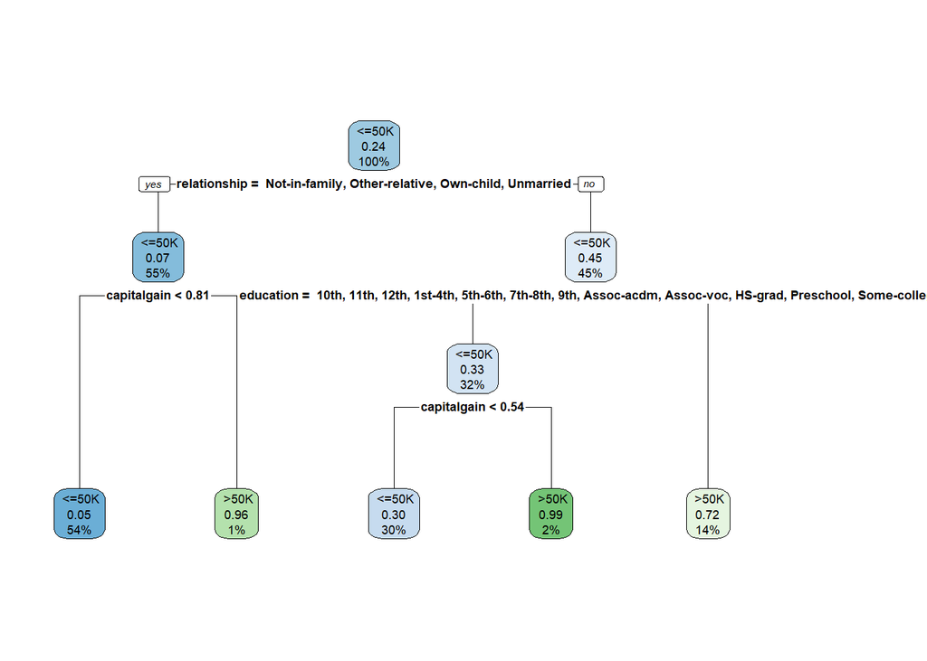

```r
rpart.plot(model1,extra=106)
```

### Prediction on train dataset

```r
library(caret)
pred1 <- predict(model1,newdata=train,type="class")
confusionMatrix(table(pred1,train$salary))
```

```
## Confusion Matrix and Statistics
##
##
## pred1     <=50K  >50K
##    <=50K  16403  2648
##    >50K     901  2841
##
##                Accuracy : 0.8443
##                  95% CI : (0.8395, 0.849)
##     No Information Rate : 0.7592
##     P-Value [Acc > NIR] : < 2.2e-16
##
##                   Kappa : 0.5223
##  Mcnemar's Test P-Value : < 2.2e-16
##
##             Sensitivity : 0.9479
##             Specificity : 0.5176
##          Pos Pred Value : 0.8610
##          Neg Pred Value : 0.7592
##              Prevalence : 0.7592
##          Detection Rate : 0.7197
##    Detection Prevalence : 0.8358
##       Balanced Accuracy : 0.7328
##
##        'Positive' Class :  <=50K
##
```

- The accuracy (correct classifications / total classifications) of the model including all the predictor variables is about ~85% % whereas balanced accuracy is about 73% on train data.
- The Kappa statistic (or value) is a metric that compares an Observed Accuracy with an Expected Accuracy (random chance). Kappa = (Observed Accuracy - Expected Accuracy) / (1 - Expected Accuracy)
- Sensitivity that is the number of correct positive predictions divided by the total number of positives is about 95%. Specificity that is the number of correct negative predictions divided by the total number of negatives is about 51%.
- Prevalence is a numeric value or matrix for the rate of the “positive” class of the data.
- Detection rate is the proportion of the whole sample where the events were detected correctly.
- Detection Prevalence tells What percentage of the full sample was predicted as <=50K.
- Balanced Accuracy is the balance between correctly predicting the >50K and <=50k. Balanced Accuracy=(sensitivity+specificity)/2

### Prediction on test dataset

```r
library(caret)
pred2 <- predict(model1,newdata=test,type="class")
confusionMatrix(table(pred2,test$salary))
```

```
## Confusion Matrix and Statistics
##
##
## pred2     <=50K  >50K
##    <=50K   7070  1168
##    >50K     346  1184
##
##                Accuracy : 0.845
##                  95% CI : (0.8377, 0.8521)
##     No Information Rate : 0.7592
##     P-Value [Acc > NIR] : < 2.2e-16
##
##                   Kappa : 0.5186
##  Mcnemar's Test P-Value : < 2.2e-16
##
##             Sensitivity : 0.9533
##             Specificity : 0.5034
##          Pos Pred Value : 0.8582
##          Neg Pred Value : 0.7739
##              Prevalence : 0.7592
##          Detection Rate : 0.7238
##    Detection Prevalence : 0.8434
##       Balanced Accuracy : 0.7284
##
##        'Positive' Class :  <=50K
##
```

- The accuracy (correct classifications / total classifications) of the model including all the predictor variables is about 84 % whereas balanced accuracy is about 73% on test data.
- The Kappa statistic (or value) is a metric that compares an Observed Accuracy with an Expected Accuracy (random chance). Kappa = (Observed Accuracy - Expected Accuracy) / (1 - Expected Accuracy)
- Sensitivity that is the number of correct positive predictions divided by the total number of positives is about 95%. Specificity that is the number of correct negative predictions divided by the total number of negatives is about 51%.
- Prevalence is a numeric value or matrix for the rate of the “positive” class of the data.
- Detection rate is the proportion of the whole sample where the events were detected correctly.
- Detection Prevalence tells What percentage of the full sample was predicted as <=50K.
- Balanced Accuracy is the balance between correctly predicting the >50K and <=50k. Balanced Accuracy=(sensitivity+specificity)/2

### Model 2 after taking significant variables only

```r
model2 <- rpart(salary ~ age + education + hoursperweek + Workclass + maritalstatus + occupation + relationship + race + sex, data=train)
model2
```

```
## n= 22793
##
## node), split, n, loss, yval, (yprob)
##       * denotes terminal node
##
## 1) root 22793 5489  <=50K (0.75918045 0.24081955)
##   2) relationship= Not-in-family, Other-relative, Own-child, Unmarried 12439  811  <=50K (0.93480183 0.06519817) *
##   3) relationship= Husband, Wife 10354 4678  <=50K (0.54819393 0.45180607)
##     6) education= 10th, 11th, 12th, 1st-4th, 5th-6th, 7th-8th, 9th, Assoc-acdm, Assoc-voc, HS-grad, Preschool, Some-college 7200 2410  <=50K (0.66527778 0.33472222) *
##     7) education= Bachelors, Doctorate, Masters, Prof-school 3154  886  >50K (0.28091313 0.71908687) *
```

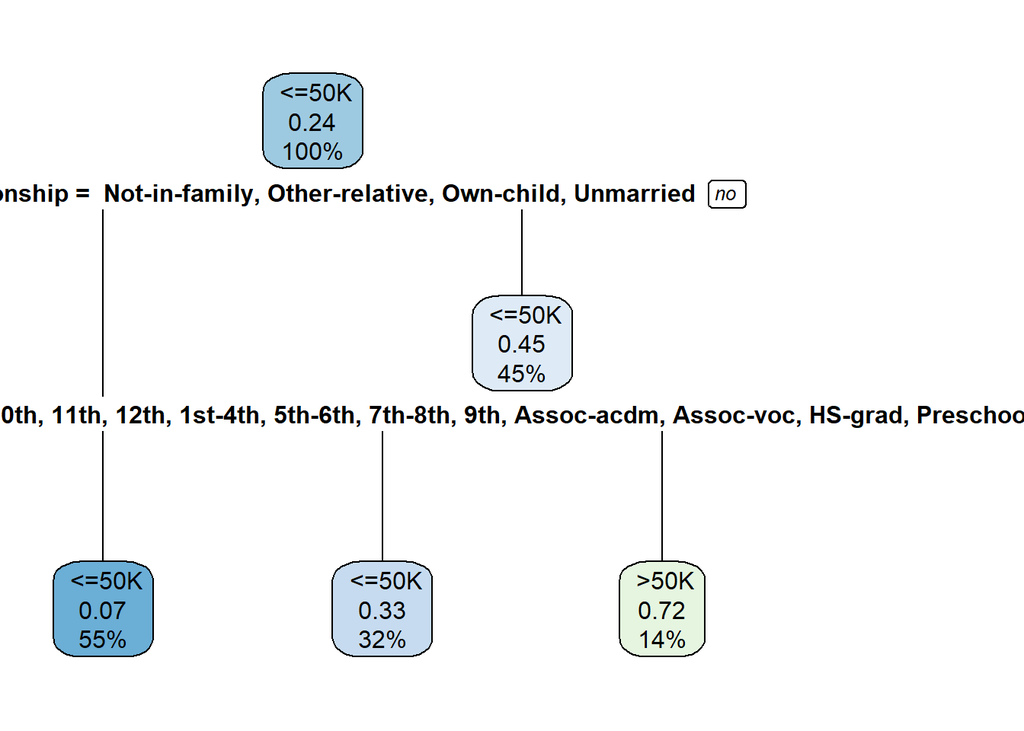

```r
rpart.plot(model2,extra=106)
```

### Prediction on train dataset

```r
library(caret)
pred3 <- predict(model2,newdata=train,type="class")
confusionMatrix(table(pred3,train$salary))
```

```
## Confusion Matrix and Statistics
##
##
## pred3     <=50K  >50K
##    <=50K  16418  3221
##    >50K     886  2268
##
##                Accuracy : 0.8198
##                  95% CI : (0.8148, 0.8248)
##     No Information Rate : 0.7592
##     P-Value [Acc > NIR] : < 2.2e-16
##
##                   Kappa : 0.4235
##  Mcnemar's Test P-Value : < 2.2e-16
##
##             Sensitivity : 0.9488
##             Specificity : 0.4132
##          Pos Pred Value : 0.8360
##          Neg Pred Value : 0.7191
##              Prevalence : 0.7592
##          Detection Rate : 0.7203
##    Detection Prevalence : 0.8616
##       Balanced Accuracy : 0.6810
##
##        'Positive' Class :  <=50K
##
```

### Prediction on test dataset

```r
pred4 <- predict(model2,newdata=test,type="class")
confusionMatrix(table(pred4,test$salary))
```

```
## Confusion Matrix and Statistics
##
##
## pred4     <=50K  >50K
##    <=50K   7077  1413
##    >50K     339   939
##
##                Accuracy : 0.8206
##                  95% CI : (0.8129, 0.8282)
##     No Information Rate : 0.7592
##     P-Value [Acc > NIR] : < 2.2e-16
##
##                   Kappa : 0.4188
##  Mcnemar's Test P-Value : < 2.2e-16
##
##             Sensitivity : 0.9543
##             Specificity : 0.3992
##          Pos Pred Value : 0.8336
##          Neg Pred Value : 0.7347
##              Prevalence : 0.7592
##          Detection Rate : 0.7245
##    Detection Prevalence : 0.8692
##       Balanced Accuracy : 0.6768
##
##        'Positive' Class :  <=50K
##
```